[figure not shown]

Contents lists available at ScienceDirect

Phytomedicine

journal homepage: www.elsevier.com/locate/phymed

[figure not shown]

Original Article

The pharmacological activity of epigallocatechin-3-gallate (EGCG) on

Alzheimer's disease animal model: A systematic review

Shuang Zhang, Qi Zhu, Jia-Yue Chen, Defang OuYang, Jia-Hong Lu<sup>⁎</sup>

*State Key Laboratory of Quality Research in Chinese Medicine, Institute of Chinese Medical Sciences, University of Macau, Taipa, Macao*

A R T I C L E I N F O

*Keywords:*

Alzheimer's disease

EGCG

Neuroprotective effects

AD animal models

Systematic review

Clinical trials

A B S T R A C T

*Background:* Alzheimer's disease (AD) is currently incurable and there is an urgent need to develop new AD

drugs. Many studies have revealed the potential neuroprotective effect of Epigallocatechin-3-O-gallate (EGCG),

the main antioxidant in green tea, on animal models of AD. However, a systematic review of these reports is

lacking.

*Purpose:* To assess the effectiveness of EGCG for AD treatment using systematic review and meta-analysis of pre-

clinical trials.

*Methods:* We conducted a systematic search of all available randomized controlled trials (RCTs) performed up to

November 2019 in the following electronic databases: ScienceDirect, Web of Science, and PubMed. 17 pre-

clinical studies assessing the effect of EGCG on animal AD models have been identified. Meta-analysis and

subgroup analysis was performed to evaluate cognition improvement of various types of AD models. The study

quality was assessed using the CAMARADES checklist and the criteria of published studies.

*Results:* Our analysis shows that the methodological quality ranges from 3 to 5, with a median score of 4.

According to meta-analysis of random-effects method, EGCG showed a positive effect in AD with shorter escape

latency (SMD= -9.24, 95%CI= -12.05 to -6.42) and decreased Aβ42 level (SD= -25.74,95%CI= -42.36 to

-9.11). Regulation of α-, β-, γ-secretase activity, inhibition of tau phosphorylation, anti-oxidation, anti-in-

flammation, anti-apoptosis, and inhibition of AchE activity are reported as the main neuroprotective mechan-

isms. Though more than 100 clinical trials have been registered on the ClinicalTrials.gov, only one clinical trial

has been conducted to test the therapeutic effects of EGCG on the AD progression and cognitive performance.

*Conclusion:* Here, we conducted this review to systematically describe the therapeutic potential of EGCG in

animal models of AD and hope to provide a more comprehensive assessment of the effects in order to design

future clinical trials. Besides, the safety, blood-brain barrier (BBB) penetration and bioavailability issues in

conducting clinical trials were also discussed.

**Introduction**

Alzheimer's disease (AD) is the most common neurodegenerative

disease featured by cognitive impairment, memory loss and un-

predictable behaviors. The disease caused a huge burden to the social

healthcare system. However, the current medication for AD is dis-

appointing (Alzheimer's, 2015, 2016; Hardy and Selkoe, 2002) and

huge efforts have been spent on drug development, though most of the

attempts failed. Amyloid plaques and neurofibrillary tangles composed

of hyper-phosphorylated tau are the major pathological hallmarks of

AD. Recent preclinical studies concluded that Aβ involved in the

memory consolidation process by selectively impairing the cAMP/PKA/

CREB pathway. The transcription factor CREB, which regulates the

expression of cAMP response element (CRE)-containing genes, plays an

essential role in learning and memory processes. Studies verified that

pathologic (nanomolar) concentrations of Aβ42 caused a sustained in-

hibition of CREB phosphorylation in hippocampal neuronal cultures

and impaired learning and memory processes (Ettcheto et al., 2018;

https://doi.org/10.1016/j.phymed.2020.153316

Received 28 May 2020; Received in revised form 17 August 2020; Accepted 30 August 2020

*Abbreviations:* Aβ, β,-amyloid peptide; ALT, alanine aminotransferase; Akt, protein kinase B; AST, aspartate transaminase; ASAP, atypical small acinar proliferation;

CHOP, binding protein homologous protein; CIN1, cervical intraepithelial neoplasia; CREB, cAMP response element binding; EGCG, Epigallocatechin-3-*O*-gallate;

ERK, extracellular signal-regulated kinase; FAS, fatty acid synthase; GFAP, glial fibrillary acidic protein; GRP78, binding immunoglobulin protein; GSH-Px, glu-

tathione peroxidase; GTE, green tea extract; HGF, hepatocyte growth factor; HGPIN, high-grade prostatic intraepithelial neoplasia; HPV, human papilloma virus;

ICAM-1, intercellular adhesion molecule-1; LFTs, liver function tests

⁎ Corresponding author.

*E-mail address:* jiahonglu@um.edu.mo (J.-H. Lu).

Phytom

edicine 79 (2020) 153316

Available online 31 August 2020

0944-7113/ ©

2020 Elsevier Gm

bH. All rights reserved.

[figure not shown]

T

Tong et al., 2001). Therefore, the Aβ and hyper-phosphorylated tau are

still the most favored targets for development of AD drugs.

Historically, green tea (*Camellia sinensis*) originated in China and

widely spread from Asia to western countries (Zaveri, 2006). Because of

the broad spectrum of pharmacological activities, EGCG displayed

therapeutic potential on various neurodegenerative diseases models.

For example, oral administration of EGCG obviously alleviated dopa-

mine neuron loss in the substantia *nigra* and tyrosine hydroxylase

protein level depletion in PD model (Levites et al., 2001). EGCG also

showed an anticonvulsive effect by reducing the neuroinflammatory

process and seizure threshold (Cano et al., 2018). The neuroprotective

effects of EGCG against Aβ-induced neuronal loss and tau toxicity in AD

models were also reported in several studies (Buetler et al., 2002;

Kaur et al., 2008). This systematic review conducted a quality assess-

ment and a meta-analysis of the studies performed on the animal AD

models in order to provide a comprehensive assessment of the effects.

The underlying mechanisms and current obstacles were also thoroughly

discussed.

**Methods**

*Overview of retrieval methods*

We performed an open-ended, language-restricted (English) search

to screen for the studies on the efficacy of EGCG on animal AD models

from databases including ScienceDirect, Web of Science, and PubMed

according to previously reported method (Zhu et al., 2019). Identical

keywords were preset for different search engines. Five keywords

(“Epigallocatechin

gallate”

OR

“Epigallocatechin-3-*O*-gallate”

OR

“Green tea extract” OR “Tea Catechin” OR “EGCG”) of the primary

domain were paired with the following subdomain words (“Alzheimer's

disease” OR “Alzheimer disease” OR “β-amyloid peptide” OR “Tau

protein” OR “amyloid plaques” OR “memory impairment” OR “cogni-

tion impairment” OR “AD”). The search was restricted to preclinical

laboratory reports in animal models. Reference lists of all included ar-

ticles were also hand-searched. Finally, the search results were reported

compliance with the guidelines of the PRISMA statement (Kapoor et al.,

2017; Moher et al., 2015).

*Study selection procedure*

The pre-established inclusion and exclusion criteria are listed below:

Table 1. Inclusion criteria and exclusion criteria for screening lit-

erature.

*Data extraction*

Two investigators separately assessed the quality of articles and

performed data collection procedures based on the inclusion criteria

(Table 1). If there is a discrepancy, the third party (Qi Zhu) will arbi-

trate through targeted discussion to resolve specific issues. The ex-

traction of detailed information of included studies mainly involves

three aspects: (1) Background information including the first author

name, and year of publication; (2) Animal species, AD model types, and

modeling methods; (3) Drug dosage, duration time, route of EGCG

administration, and methods of outcome assessment.

*Quality of evidence*

Assessment criteria were established according to the CAMARADES

study quality checklist (Moher et al., 2015) and the standards of pub-

lished criteria (Macleod et al., 2009b) and modified according to the

characteristics of experimental AD models. Then the methodological

quality of studies was assessed using the following criteria: (1) sample

size calculation; (2) random allocation of treatment/control group; (3)

blinded assessment of outcome; (4) appropriate animal species and AD

models; (5) publication in a peer-reviewed journal; (6) compliance with

animal welfare regulations and (7) statement of potential conflicts of

interest. Each study was given a quality score out of a maximum total of

seven points, and the group median was calculated.

**Table 1**

Inclusion criteria and exclusion criteria for screening literature.

Inclusion criteria:

Studies of EGCG administration on animal AD models;

EGCG is not tested in combination with other pharmacological interventions;

Free EGCG forms, not nanoparticles or EGCG analogs;

Laboratory animal is limited to mice/rats only and there is no restrictions on age,

gender, or strain;

Depicting a group of control animals;

Raw data is independent of other studies and there is no restriction to methods of

outcome assessment.

Exclusion criteria:

No original data;

Not the original study results;

Case reports, reviews, editorials, comments, abstracts or letters et al.;

No access to the databases.

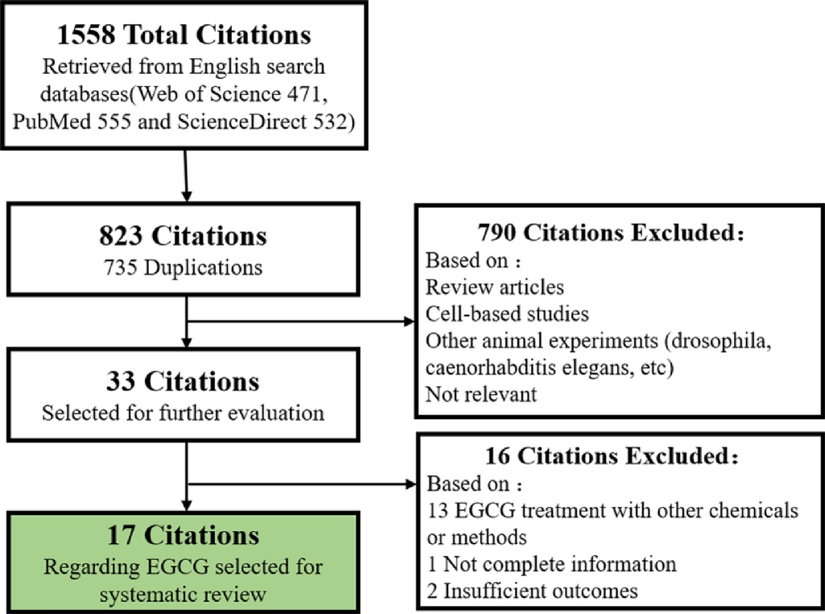

**Fig. 1.** Study selection flowchart.

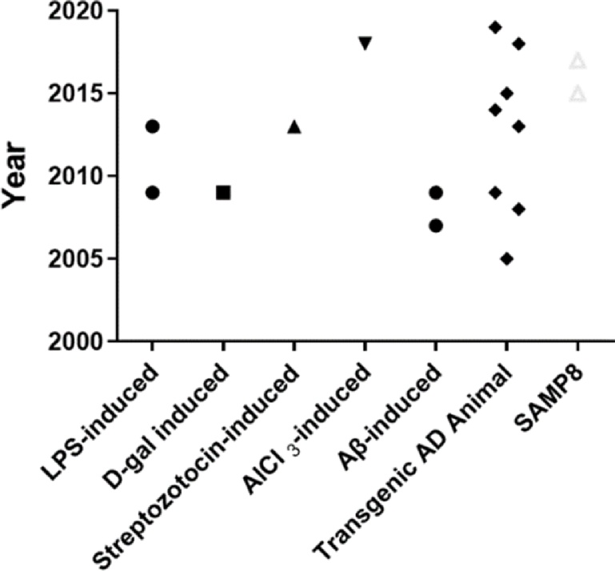

**Fig. 2.** Different AD Models.

*S. Zhang, et al.*

*Phytom*

*edicine 79 (2020) 153316*

2

**Results**

*Results of retrieved literature*

A total of 1558 articles were identified initially (471 from Web of

Science, 555 from PubMed and 532 from ScienceDirect). 33 articles

remained after screening by the titles and abstracts, of which 13 articles

were removed for combination with other pharmacological interven-

tions. Another 3 articles were excluded for insufficient outcomes or no

full text. Finally, 17 whole animal studies were feasible for the sys-

tematic review (Biasibetti et al., 2013; Cano et al., 2019; Chang et al.,

2015; Du et al., 2018; Guo et al., 2017; He et al., 2009; Jia et al., 2013;

Lee et al., 2009a, 2013, 2009b; Lin et al., 2009; Liu et al., 2014;

Rasoolijazi et al., 2007; Rezai-Zadeh et al., 2008, 2005; Singh et al.,

2018; Walker et al., 2015). The study selection process is illustrated in a

flowchart (Fig. 1).

Of the selected 17 articles, two species were included. 3 studies

chose rats (total animal number 54) and 14 studies chose mice (total

Wistar rats (*n* = 3), SAMP8 and SAMR1 Mice (*n* = 2), B6/SJL mice

(*n* = 3), C57BL/6 J mice (*n* = 5), ICR mice (*n* = 3), Kunming mice

(*n* = 1). There were 6 articles using male animals, 3 articles using fe-

male animals, 3 studies using both males and females, and the other 5

studies not mentioning the sex of the animals used.

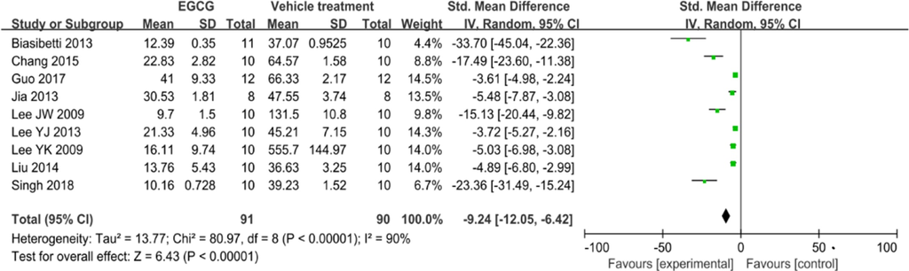

**Fig. 3.** Forest plot for comparison: EGCG versus vehicle treatment. Outcome: Escape latency (*sec*) in the Morris water maze test.

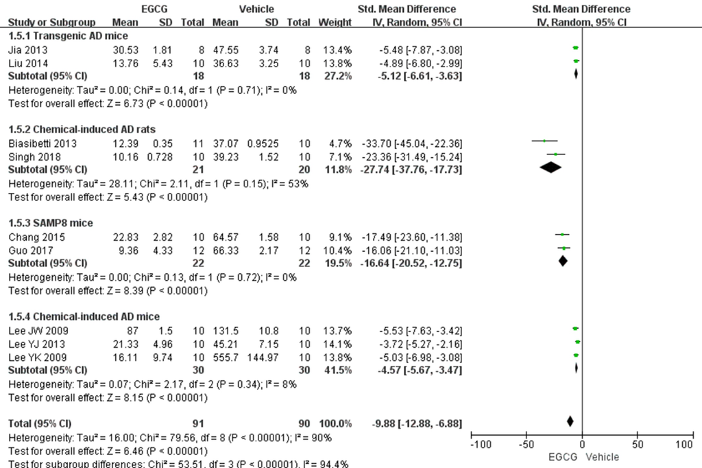

**Fig. 4.** Subgroup comparisons of different types of AD animal models after EGCG treatment (Morris water maze).

*S. Zhang, et al.*

*Phytom*

*edicine 79 (2020) 153316*

3

*Study characteristics*

*AD animal models*

Animal models are commonly used for brain aging studies. Among

these retrieved publications, five kinds of chemical-induced AD models

were involved. They were Aβ-induced, LPS-induced,

D-gal-induced,

streptozotocin-induced and aluminum chloride (AlCl3)-induced AD

models respectively (Fig. 2). To mimic brain aging and cognitive defi-

cits, Homa Rasoolijazi (Rasoolijazi et al., 2007) injected 2 nmol/µl

Aβ1–40 (4 µl) into the hippocampal fissure of male Wistar rats and Jae

Woong Lee (Lee et al., 2009a) injected 0.5 µg Aβ1–42 into the ventricles

of male ICR mice. In addition, the LPS-induced AD model was used in

two selected studies. Lee, Y. K. (Lee et al., 2009b) injected LPS directly

into the third ventricle of the mice (1 μg/mouse) and Lee, Y. J.

(Lee et al., 2013) injected 250 μg/kg LPS into mice intraperitoneally for

7 days to stimulate mice with neuronal degeneration and spatial

memory impairment. Besides, subcutaneous injection of D-gal; lateral

ventricle injection of streptozotocin; oral administration of AlCl3 was

also used to simulate cognitive impairment AD models. The common

feature of these chemical and lesion-induced models is their ability to

replicate the cognitive impairment symptoms as well as the neurode-

generation and neuroinflammation phenotypes of AD.

Besides the above-mentioned toxin-induced models, genetically

modified mice provide a model that is closer to human AD pathology.

The transgenic models such as APP/PS1, TgCRND8 and Tg2576 mice

are based on the over-expression of mutant APP and/or PS1 protein

these are associated with familial AD (Van Dam and De Deyn, 2011). A

common feature of these three kinds of transgenic mice is that the

amount of APP transgene expression is several times higher than the

endogenous murine APP (Maia et al., 2013). Furthermore, all these

transgenic mouse models are progressing with cortical and hippo-

campal β-amyloid peptide accumulation and caused profound cognitive

deficits.

In addition to the AD models of toxin induction and genetic mod-

ification, two studies (Chang et al., 2015; Guo et al., 2017) utilized the

senescence-accelerated prone mice (SAMP8) to mimic sporadic AD.

Because more than 99% of clinical cases are sporadic late-onset AD

(van der Flier et al., 2011), SAMP8 mice are considered a suitable

model for exploring the pathogenesis and therapeutic treatments of AD.

*Neuroprotective effects of EGCG on AD models*

Cognitive function impairment is the major clinic symptom of AD

thus the assessment of memory-related behavioral function is the most

important assay to monitor the cognitive function in AD mice models.

Morris Water Maze (MWM), the widely used behavioral tests, relies on

recording the route of mice to navigate itself from start locations

around the perimeter of an open swimming area to locate an under-

water escape platform. According to the time it takes to find the plat-

form (escape latency), time in the target quadrant, and a number of

crossings over the platform position, the reference memory could be

surmised. As the pathological hallmarks, Aβ accumulation and neuro-

fibrillary tangles formation reflect the neuropathological changes in AD

mice models. The data of MWM behavioral tests and Aβ content in the

brain were extracted from the studies and the meta-analysis was con-

ducted for a more objective appraisal of the research evidence.

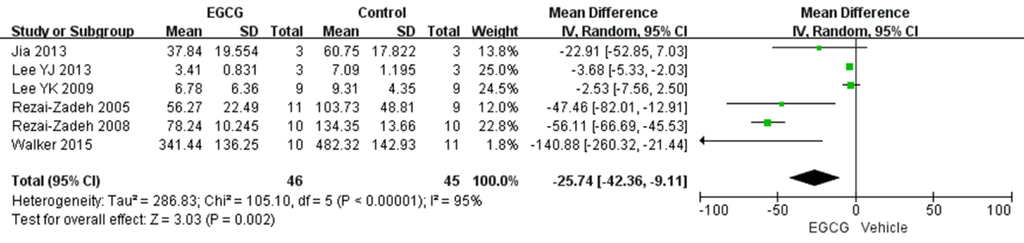

**Fig. 5.** Forest plot for comparison: EGCG versus vehicle treatment. Outcome: Aβ1–42 pg/mg in the hippocampus measured by ELISA.

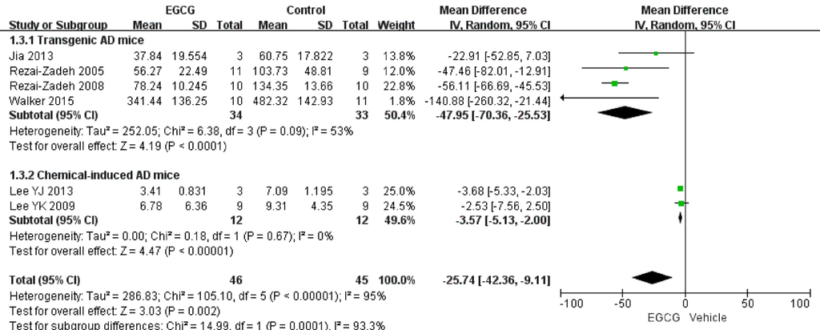

**Fig. 6.** Subgroup comparisons of transgenic or non-transgenic AD animals after EGCG treatment (insoluble Aβ).

*S. Zhang, et al.*

*Phytom*

*edicine 79 (2020) 153316*

4

**Table 2**

Main neuroprotective mechanisms and outcomes of EGCG towards AD.

**Publication**

**Model**

**EGCG administration**

**Outcome measures**

**Neuroprotective mechanisms**

Rezai-Zadeh, K

et al.,2005

Tg APPsw line 2576

①EGCG (20 mg/kg)

i.p. for 2 months

②EGCG (10 μg/mouse)

intracerebroventricular

injection for once.

Level of Aβ1–40, 42

Product of nonamyloidogenic APP

processing sAPP-α

Activity assays of α-, β- and γ-secretase

G8 Immunohistochemistry and thioflavin S

Histochemistry test condition of Aβ

deposition

Enhancing the nonamyloidogenic α-secretase

proteolytic pathway

Homa Rasoolijazi,2007

Aβ-induced

Alzheimer's Rat

EGCG (10 mg/kg)

i.p. for three weeks

Psychomotor coordination (PMC)

performance

Spontaneous motor activity index

N/A

Rezai-Zadeh, K

et al.,2008

Tg APPsw line 2576

①EGCG (50 mg/kg)

orally administered for 6

months

②EGCG (20 mg/kg)

i.p. for 2 months

Radial arm water maze (RAWM)

Level of Aβ1–40, 42

Product of nonamyloidogenic APP

processing sAPP-α

Levels of phospho-tau and total tau

Immunohistochemistry and Congo red

histochemistry test condition of Aβ

deposition

N/A

Chih-Li Lin, et al.,2009

Tg APPsw line 2576

EGCG (20 mg/kg)

orally administered for 4

months

Morris water maze

Level of Aβ1–40, 42

Changes of c-Abl-FE65 complex interaction

and GSK3β-Tyr<sup>216</sup>phosphorylation

Inhibiting APP proteolytic processing;

Inhibiting cAbl/FE65 complex nuclear

translocation and GSK3β activation

Lee, YK et al. 2009

LPS-induced mice

EGCG (1.5 or 3 mg/kg)

orally administered for 3 weeks

Morris water maze test

Passive avoidance performance

Level of Aβ1–42

Activity assays of β- and γ-secretase

Levels of inflammatory factors- GFAP, C0X-

2 and iNOS

Level of apoptotic neurocytes

Anti-inflammation;

Anti-apoptosis;

Inhibiting beta- and gamma-secretase activity

He, Miao et al.,2009

D-gal induced mice

EGCG (2 or 6 mg/kg)

intragastrical (i.g.) for 1month

Locomotor Activity Testing

SMG-2 Water Maze

Activities of T-SOD and GSH-Px

(antioxidant enzymes)

Contents of oxidative injury maker-MDA

Level of apoptosis protein-cleaved caspase-

3

Anti-inflammation;

Anti-apoptosis

Lee, JW et al., 2009

Aβ-induced

Alzheimer's mice

EGCG (1.5 or 3 mg/kg)

orally administered for 3 weeks

Passive avoidance performance

Water maze test

Level of Aβ1–42

Activity assays of α-, β- and γ-secretase

Changes of JNK1, ERK2, and p38 MAP

kinase

Level of inflammatory factors -NF-κB

Level of apoptotic neurocytes

Anti-inflammation;

Anti-apoptosis;

Modulating secretases activity;

Inhibiting Aβ fibrillization; Inhibiting ERK/

NF-kappaB pathway.

Lee, YJ et al., 2013

LPS-induced mice

EGCG (1.5 or 3 mg/kg)

orally administered for 3 weeks

Morris water maze

Probe test

Passive avoidance performance

Level of Aβ1–42

Activity assays of β- and γ-secretase

Levels of inflammatory factors- GFAP, COX-

2 and iNOS(in addition to TNF-α, IL-1β, M-

CSF, ICAM-1, IL-16)

Anti-neuroinflammation;

Inhibiting cleavage secretase activities

Jia, N et al., 2013

APP/PS1 transgenic

mice

EGCG (2 or 6 mg/kg/day)

intragastrical for 1 month

Morris water maze test

Level of Aβ1–42

Immunohistochemistry test IRS-1pSer636

positive cells

Level of inflammatory-related proteins-IRS-

1, JNK, Akt and GSK3β

Remission insulin resistance by restoring IRS-1

signaling;

Inhibiting TNF-α/JNK pathway;

Reducing tau hyperphosphorylation

Biasibetti, R et al.,2013

Streptozotocin-

induced rats

EGCG (10 mg/kg/day)

i.g. for 1 month

Morris water maze

Acetylcholinesterase activity

Glial activation related proteins- GFAP and

S100B

Oxidative stress markers- NO, ROS

Anti-oxidant enzyme-Glutathione

peroxidase activity

Anti-neuroinflammation;Antioxidant action;

Decreasing AchE activity

Mingyan Liu et al.,2014

APP/PS1 transgenic

mice

EGCG (2 mg/kg)

i.g. for 1 month

Morris Water Maze Test

Passive Avoidance Test

Locomotivity Test

Level of Aβ1–40 and APP

Level of NGF and NGF-related TrkA/

p75NTR signaling

Level of apoptotic neurocytes

Increasing the level of NGF;

Balancing TrkA/p75NTR signaling;

Anti-apoptosis

Walker, JM et al.,2015

TgCRND8 mice

Barnes maze,

Nest building

N/A

(*continued on next page*)

*S. Zhang, et al.*

*Phytom*

*edicine 79 (2020) 153316*

5

*Morris water maze analysis*

Nine studies on MWM tests were used to evaluate cognition and

memory function in experimental AD models. A total number of 91

animal was included and treated with EGCG at different doses, with 90

vehicle-treated animal added as controls. Escape latency (*sec*) was used

in the correlation because it represents the difference in memory

function between EGCG and vehicle treatment groups. Univariate sta-

tistical analysis was performed using Revman 5.3 software. In pre-

clinical AD models, EGCG showed strong efficacy in shortening escape

latency (*p* < 0.00001) compared with vehicle-treated animals, SMD

−9.24 (95% CI = −12.05 to −6.42, Fig 3). Due to detection of sig-

nificant heterogeneity (I<sup>2</sup>==90%), the random-effects model was

used. Subgroup comparison was also conducted according to different

types of AD models (Fig 4). The elevated heterogeneity may be ex-

plained by the use of different AD models (transgenic/chemicel-induced

models) and animal strains (mouse/rat).

*Aβ**1–42* *detection analysis*

Pathological determination of insoluble Aβ1–42 in the hippocampus

hippocampus was significantly reduced (*p* = 0.002) compared to the

a subgroup comparison (Fig 6). The elevated heterogeneity may be

explained by the use of different models (transgenic AD model/che-

micel-induced AD model).

*Neuroprotective mechanisms of EGCG on AD models*

The accumulated toxic Aβ peptide and hyperphosphorylated tau

protein, increased oxidative stress, neuroinflammation, insulin re-

sistance and aberrant metabolism have all been proposed to be involved

in the etiology and pathogenesis of AD (Ansari and Emerald, 2019;

Minter et al., 2016; Morris et al., 2011; Riek and Eisenberg, 2016).

Table 2 summarized the main neuroprotective mechanisms and efficacy

of EGCG on AD models in these retrieved publications. In the studies,

EGCG has been revealed to exert anti-oxidation, anti-inflammation,

anti-apoptosis, regulation of α-, β-, γ-secretase activity, inhibition of

hyperphosphorylation of tau and reduction of AchE activity (Fig.7). In

addition, two articles reported the effects of EGCG on levels of nepri-

lysin and synaptic proteins in the brain.

Cognitive and memory impairment is the most direct phenotype

associated with AD and mitigating this dysfunction is the most im-

portant index in assessing successful modeling and therapeutic efficacy

of candidate drugs. Most of the publications listed here (87.5%) per-

formed behavioral tests on AD animals. The main behavioral tests in-

cluding the Morris water maze, locomotivity test, performance of pas-

sive avoidance and open field test. These tests are frequently used to

evaluate spatial learning and memory functions.

*EGCG decreased the accumulation of Aβ*. Aβ peptide is produced through

endoproteolytic processing from amyloid precursor protein (APP) by β-

and γ-secretase-mediated cleavage. Alternatively, APP can be cleaved

within the Aβ sequence by α-secretase which hinders the formation of

soluble or insoluble Aβ levels and rescued cognitive impairment. Three

studies have reported changes in secretase activity caused by EGCG.

Kavon Rezai-Zadeh (Rezai-Zadeh et al., 2005) showed that EGCG acts

as an α-secretase agonist which upregulated nonamyloidogenic APP

proteolysis and reduced the deposition of β-amyloid plaques in Tg

APPsw mice. They also detected reduced soluble and insoluble Aβ1–40,

42 <sup>levels with elevated levels of α-CTF and sAPP-α in brain tissue as</sup>

supporting evidence. Besides, Jae Woong Lee et al. (Lee et al., 2009a)

and Young Kyoung Lee et al. (Lee et al., 2009b) verified that EGCG

treatment downregulated β- and γ-secretase activities and eventually

decreased toxic Aβ levels in the cortex and hippocampus.

*EGCG regulates GSK3β activity*. Tau hyperphosphorylation contributes

to the formation of the neurofibrillary tangle (NFT) and causes

neuropathological lesions (Takashima, 2006). There are also three

studies revealed the potential role of EGCG on the glycogen synthase

kinase-3β (GSK-3β), a pivotal tau kinase in the brain promoting the

production of paired helical filament in NFT. Chih-Li Lin et al.

(Lin

et

al.,

2009)

reported

that

EGCG

relieved

Aβ-induced

neurotoxicity by inhibiting GSK3β activation and c-Ab/FE65 complex

**Table 2** (*continued*)

EGCG (50 mg/kg/day)

orally administered for 4

months

Open-field

Level of soluble Aβ

Xiang Chang et al.,2015

SAMP8 mice

EGCG (5 or15 mg/kg)

i.g. for 2 months

Morris water maze test

Level of Aβ1–42

Expression of neprilysin

Apoptosis proteins-Bcl-2, Bax

Enhancing neprilysin activity;

Anti-apoptosis

Guo, Y. F. et al.,2017

SAMP8 mice

EGCG(5 or 15 mg/kg)

orally administered for 4

months

Morris water maze test

Locomotor activity test

Y-maze test

Level of Aβ1–42 and

phosphorylated-<sup>tauSer396</sup>

Level of β-secretase

Synaptophysin(SYN) and postsynaptic

density protein 95 (PSD95);

Increasing level of synaptic proteins;

Inhibiting β-secretase activity

Du, K. et al.,2018

APP/PS1 transgenic

mice

EGCG (2 mg/kg/day)

i.g. for 1 month

Apoptosis protein-cleaved-caspase 3

ER stress-associated proteins- GRP78,

CHOP and cleaved-caspase 12

Inhibiting ER stress-associated neuronal

apoptosis

Singh, N. A. et al.,2018

AlCl3-induced AD

rats

EGCG or nanoEGCG (10 mg/

kg)

i.g. for 1 month

Morris Water Maze

Open Field

Novel Object Recognition

Level of Aβ1–42 and APP

Acetylcholinesterase activity

Oxidative stress markers-NO, ROS

Changes of PDK1, GSK3β

Antioxidant;

Decreasing AchE activity;

Reducing tau hyperphosphorylation

Amanda Cano. et al.,2019

APP/PS1 transgenic

mice

EGCG or nanoEGCG (40 mg/

kg)

orally administered for 3

months

Morris water maze test

Novel Object Recognition test

Soluable and insoluable Aβ

Inhibiting Aβ fibrillization

*S. Zhang, et al.*

*Phytom*

*edicine 79 (2020) 153316*

6

nuclear translocation in Tg2576 transgenic mice. They demonstrated

that EGCG treatment decreased GSK3β activation by monitoring Tyr<sup>216</sup>

phosphorylation level. Ning Jia et al. (Jia et al., 2013) and Singh, N.A.

et al. (Singh et al., 2018) also showed that EGCG was able to increase

hippocampal p-GSK3βSer9 levels by restoring the downstream Akt/

GSK-3β signaling and reduce the expression levels of GSK3β in APP/

PS1 mice or AlCl3-induced AD rats.

*EGCG ameliorates oxidative stress*. Oxidative stress is recognized, at least

in part, to be an important motivation of AD (Bonda et al., 2010). Key

antioxidant enzymes such as catalase (CAT), superoxide dismutase

(SOD), and glutathione peroxidase (GSH-Px) can protect brain tissue

from cell damage caused by oxidative stress. Malondialdehyde (MDA)

produced by lipid peroxidation is a marker for oxidative damage. Three

studies have indicated that EGCG exerted antioxidant function in

murine AD models. Miao He et al. (He et al., 2009) demonstrated

that EGCG enhanced the activity of T-SOD and GSH-Px and reduced

MDA

content

in

the

hippocampus.

Regina

Biasibetti

et

al.

(Biasibetti et al., 2013) and Singh, N. A. et al. (Singh et al., 2018)

reported that EGCG relieved hippocampal oxidation and nitrosative

stress

by

reducing

reactive

oxygen

species(ROS)

level

and

NO

production

in

streptozotocin-induced

and

AlCl3-induced

models

respectively.

*EGCG*

*exerts*

*anti-neuroinflammation*

*action*. Neuroinflammation

promotes AD pathogenesis as much as Aβ plaques and neurofibrillary

tangles rather than being activated by them (Zhang et al., 2013). Three

studies showed the anti-inflammatory function of EGCG. Glial fibrillary

acidic protein (GFAP), inducible nitric oxide synthetase (iNOS) and

cyclooxygenase-2

(COX-2)

are

representative

markers

of

neuroinflammation. Both Young Kyoung Lee et al. (Lee et al., 2009b)

and Lee Young-Jung et al. Lee et al., 2013 found that EGCG prevented

LPS-induced elevation of GFAP, iNOS, and COX-2. Lee Young-Jung

et

al.

further

demonstrated

that

EGCG

prevented

LPS-induced

astrocytes activation and cytokines elevation including IL-1β, IL-16,

TNF-α,

soluble

intercellular

adhesion

molecule-1

(sICAM-1)

and

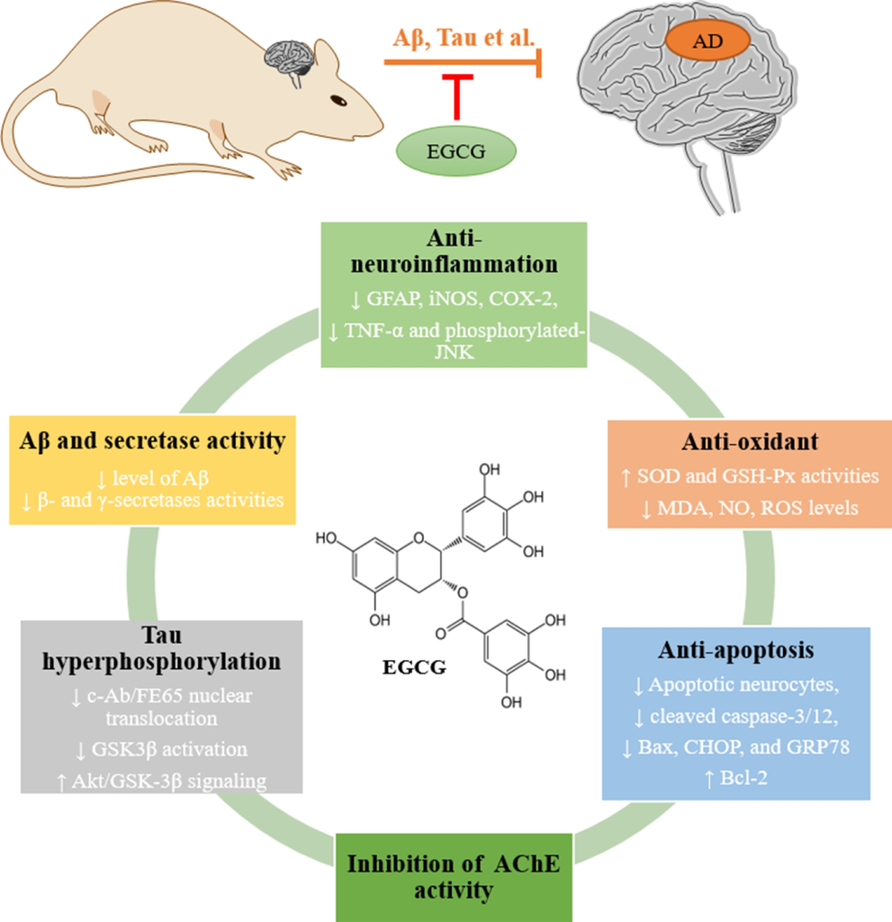

**Fig. 7.** Neuroprotection mechanisms of EGCG.

*S. Zhang, et al.*

*Phytom*

*edicine 79 (2020) 153316*

7

macrophage colony-stimulating factor (M-CSF). Besides, Ning Jia et al.

(Jia et al., 2013) demonstrated that EGCG exhibited the anti-

inflammatory

effect

by

reducing

hippocampal

TNF-α

and

phosphorylated-JNK levels.

*EGCG exerts anti-apoptosis action*. Five studies showed that EGCG

administration

could

effectively

reduce

neuronal

apoptosis

and

improve the functional performance of AD animals. Miao He et al.

(He et al., 2009), Jae Woong Lee et al. (Lee et al., 2009a) and Mingyan

Liu et al. (Liu et al., 2014) all demonstrated that apoptotic neurons in

the hippocampus were decreased by EGCG intake in

D-Galactose-

induced

AD

model,

Aβ1–42-induced

AD

model

and

APP/PS1

transgenic mice, respectively. Caspase 3 cleavage is a typical mark of

apoptosis, three publications (Miao HE et al. (He et al., 2009), Du, K.

et al. (Du et al., 2018) and Mingyan Liu et al. (Liu et al., 2014)) reported

that EGCG administration reduced the expression of cleaved caspase 3

and the level of apoptotic neurons in the hippocampus. Furthermore,

Xiang Chang et al. (Chang et al., 2015) found that EGCG administration

could up-regulate the anti-apoptotic protein Bcl-2 and amplify the Bcl-

2/Bax ratio. Du, K. et al. (Du et al., 2018) revealed the role of EGCG in

endoplasmic reticulum stress-mediated apoptosis. They found that

EGCG treatment reduced the expression levels of CHOP, GRP78 and

cleaved caspase 12 in the cerebral cortex of APP/PS1mice (Du et al.,

2018).

*EGCG*

*inhibits*

*AChE*

*activity*. As

the

main

neurotransmitter,

acetylcholine (ACh) maintains brain function such as cognition and

learning ability and short-term memory. In addition, the elevated level

of acetylcholinesterase (AChE) is associated with the loss of cholinergic

efficacy of EGCG in preventing the turnover of the ACh to alleviate

memory loss symptoms. Both Singh, N.A. et al. (Singh et al., 2018) and

Regina Biasibetti (Biasibetti et al., 2013) reported that EGCG was

capable to impair the AchE activity and prevent cholinergic neuron loss

in the cortex and hippocampus.

*Others*. Other mechanisms involved in EGCG neuroprotection have also

been proposed: regulation of neprilysin, synaptic proteins and nerve

growth factor (NGF) levels. In detail, Xiang Chang (Chang et al., 2015)

found that EGCG can up-regulate the expression of neprilysin, which

helps to degrade the abnormally folded Aβ peptide in neural tissue. Guo

Yufang (Guo et al., 2017) reported that EGCG can relief Aβ-induced

synaptic dysfunction by rescuing the decreased levels of synaptic

protein marker synaptophysin (SNY) and postsynaptic density protein

95 (PSD95). Besides, Mingyan Liu et al.(Liu et al., 2014) demonstrated

that EGCG could ameliorate the NGF starvation in AD mice by

increasing both NGF and proNGF levels and maintain the TrkA/

p75NTR balance.

*Analysis of EGCG clinical trials*

*Recruitment status of current EGCG clinical trials*

(*n* = 67), and the other status of clinical trials are: not yet recruiting

(*n* = 1); recruiting (*n* = 11); enrolling by invitation (*n* = 3); active, not

recruiting (*n* = 4); terminated (*n* = 9); withdrawn (*n* = 2) and un-

known status (*n* = 7).

*Clinical trial on the cognitive improvements of EGCG in down syndrome*

Due to triplication of the APP gene in trisomy of chromosome 21,

90% of individuals with Down syndrome (DS) showed neurodegen-

erative features of AD after age 60. Alzheimer's disease in DS often

presents with cognitive decline, behavioral symptoms, myoclonus/sei-

zures (Zis and Strydom, 2018). A double-blind, placebo-controlled,

phase 2, single-center trial of EGCG for DS treatment has been com-

pleted. After the 12 months of EGCG treatment, higher preservation of

memory and an improvement of executive functioning compared with

the placebo have been observed, as measured with the ABAS-II func-

tional academics score (*p* < 0.002). The efficacy of EGCG was sug-

gested to depend, at least partly, on the ability of EGCG to inhibit

DYRK1A kinase activity, a strong candidate gene for learning defects

associated with DS (De la Torre et al., 2014).

*Safety of EGCG reported by the completed clinical trials*

67 clinical trials have completed the recruitment process. Among

these trials, 12 studies have reported relevant results. The condition or

disease of the clinical trials include prostate cancer (*n* = 3); breast

cancer (*n* = 3); Down's syndrome (*n* = 1); HPV infection (*n* = 1);

ulcerative colitis (*n* = 1); bladder cancer (*n* = 1); multiple sclerosis

(*n* = 1) and lymphocytic leukemia (*n* = 1). The general characteristics

of completed clinical trials are shown in Table 3.

In preclinical and phase I clinical trials, it has been shown that

bioavailability of EGCG is increased when it is consumed on a fasting

basis. However, the rate of hepatotoxicity is also increased (Crew et al.,

2012; Wu et al., 2011). The FDA does not allow human studies of

Polyphenon E on a fasting basis, as mortality of dog is high when

1200 mg Polyphenon E is used in the fasting state (Kapetanovic et al.,

2009). The highest safe dose for more than a month of treatment al-

lowed by FDA is 800 mg of EGCG daily with food.

Among these clinical trials, 6 (50%) studies selected 800 mg EGCG

as a daily dose (duration from 6 weeks to 1 year) and EGCG was well

tolerated with no grade 2 or higher toxicities except for one trial of

multiple sclerosis showing a high risk of hepatotoxicity (Lovera et al.,

2015). The grade of adverse events (AEs) compliances with the stan-

dardized definitions published by the National Cancer Institute to de-

scribe the severity of organ toxicity for patients (https://ctep.cancer.

gov/). AEs including nausea, dizziness, stomach ache, heartburn, ab-

dominal pain, headache, and muscle pain has been reported after EGCG

treatment. However, most of the reported events were rated as mild

events with no significant difference with placebo group (Bettuzzi et al.,

2006; Campbell et al., 2010; Chow et al., 2001, 2003; de la Torre et al.,

2016; Dryden et al., 2013; Garcia et al., 2014; Lovera et al., 2015;

McLarty et al., 2009; Samavat et al., 2019). Recent studies using

Polyphenon E to treat chronic lymphocytic leukemia have escalated the

daily dose to 4000 mg with reasonable safety for six months treatment

(16%

discontinuation

due

to

elevated

liver

function

tests)

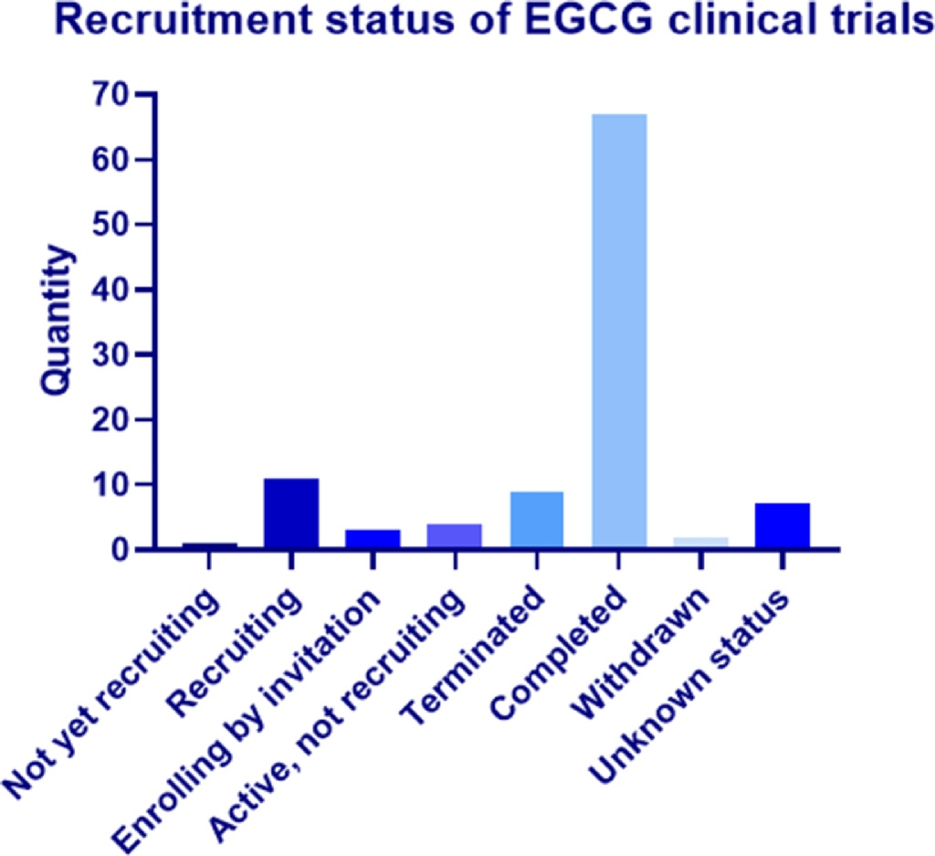

**Fig. 8.** Recruitment status of EGCG clinical trials.

*S. Zhang, et al.*

*Phytom*

*edicine 79 (2020) 153316*

8

**Table 3**

Safety of EGCG reported by the completed clinical trials.

**No.**

**Trials**

**Disease**

**Type of study**

**Study Phase**

**N (Case:**

**Control)**

**Mean age**

**(SD/ Range)**

**Follow-up**

**time**

**Intervention**

**Main results**

**Safety and Tolerability**

1

de la Torre R,

2016

Down's syndrome

Double-blind,

randomised, placebo-

controlled trial

Phase 2

84

22(4)

12 months

600 or 800 mg EGCG

daily

Improvement of executive function

and recognition memory.

Well tolerated;

AEs were mainly mild with no differences

between the study groups.

2

Jesus Lovera

MD, 2015

Multiple Sclerosis

Randomized, placebo-

controlled trial

Phase 2

13

48(33–59)

12 months

800 mg EGCG daily

Not futile at increasing brain NAA

level.

A high risk of hepatotoxicity with

elevation of liver enzymes (5/7

participants);

common AEs were nausea and abdominal

pain.

4

Nagi B. Kumar,

2016

Prostatic

Hyperplasia

Randomized, placebo-

controlled trial

Phase 2

97

63.02(7.9)

12 months

400 mg EGCG daily

EGCG accumulated in plasma (*p*

<0.001) in men with baseline

HGPIN or ASAP.

Well tolerated;

no liver or other dose limiting toxicities.

5

McLarty J,

2009

Prostate Cancer

Open-label, single-arm

trial

Phase 2

33

58.6(7.1)

6 weeks

polyphenol E

(containing 800 mg

EGCG) daily

Levels of serum HGF, VEGF and

PSA decreased in men with prostate

cancer (*p* < 0.03).

No AEs on liver function (albumin,

aspartate aminotransferase, alkaline

phosphatase, and amylase significantly

decreased).

6

Zhang Z, 2016

Prostate Cancer

Randomized, double-

blind, placebo-

controlled trial

Phase Not

Applicable

89

63(6.3)

5 months

600 mg EGCG daily

No significant difference in FAS or

Ki-67 changes.

No difference for AEs between treatment

and placebo groups.

7

Samavat H,

2019

Breast Cancer

Randomized, double-

blind placebo-

controlled trial

Phase 2

1075

59.8(5.02)

12 months

GTE containing

843 mg EGCG daily

Increasing levels of blood estradiol

(*p* = 0.02) and bioavailable

estradiol (*p* = 0.03).

Common AEs were infections and

gastrointestinal disorders (no significant

difference);

well tolerated;

AEs > 98% were mild (grade 1 or 2);

8

Julie l.

Campbell,

2010

Breast Cancer

Open-label, single-arm

trial

Phase 2

32

51.8(7.7)

2–4 weeks

800 mg EGCG daily

No significant change in serum HGF

level.

Well tolerated;

no grade 2 or higher toxicities;

no significant elevation of liver or

pancreatic enzymes.

9

Katherine D.

Crew,2012

Breast Cancer

Randomized, double-

blinded, placebo-

controlled trial

Phase 1

40

52

(36 to 64)

6 months

polyphenon E of 400,

600 or 800 mg twice

daily

reduction estradiol level (*p* = 0.05)

and SHBG level (*p* = 0.03);

Common AEs (mainly

grade 1) are gastrointestinal disorder

(nausea; indigestion; diarrhea;

constipation, etc.).

10

Garcia FA,

2013

HPV infection

Randomized, double-

blind, placebo-

controlled trial

Phase 2

98

28.28

(8.39)

4 months

Polyphenon E

(containing 800 mg

EGCG) daily

No significant change in clearance

of high-risk HPV and related CIN1.

Well tolerated;

97% were grade 1 or grade 2 AEs (nausea,

vomiting, cervicitis, sinus infection,

dizziness, back pain, stomach ache).

11

GW Dryden,

2013

Ulcerative Colitis

Randomized, double-

blinded, placebo-

controlled trial.

Phase 2

20

40(15)

2 months

400 mg or 800 mg

EGCG daily

Polyphenon E showed therapeutic

benefit (*p* = 0.03).

No serious AEs (grade 1 or 2);

no significant differences of bilirubin,

alkaline phosphatase, ALT, and AST levels.

12

Shanafelt TD,

2013

Lymphocytic

Leukemia

Single group trial

Phase 2

42

60

(41 to 78)

6 months

2000 mg EGCG twice

daily

Declination of absolute lymphocyte

count (30%) and/or

lymphadenopathy (70%).

Well tolerated;

(nausea; abdominal pain; diarrhea;

yperglycemia);

*S. Zhang, et al.*

*Phytom*

*edicine 79 (2020) 153316*

9

(Shanafelt et al., 2013). Besides, one trial has conducted the maximum

tolerated dose test (25% dose-limiting toxicity), and 600 mg Poly E

twice daily has been defined for breast cancer patients (Campbell et al.,

2010). Therefore, the higher dose may be tolerable for cancer treatment

but the dose of 800 mg daily is probably the dose that most patients

would be able to consistently tolerate.

*Methodological quality of included studies*

The methodological quality scores of selected studies ranged from 3

to 5 out of a total 7 points and the median score is 4. All the papers were

published in a peer-reviewed journal with proper animal models;

compliance with animal welfare regulations was reported by 16 pub-

publications (35.3%), and blinded assessment of outcome was only

conducted in 1 study. In addition, sample size calculation was not

conducted

in

publications

identified

in

this

systematic

review

(Macleod et al., 2009a). All the details are shown in Table 4.

**Discussion**

Up to now, the FDA approved drugs for AD treatment are limited to

acetylcholinesterase inhibitors (donepezil, galantamine and rivas-

tigmine) indicated for mild‐to‐moderate AD and *N*‐methyl‐D‐aspartate

receptor antagonist, memantine indicated for moderate‐to‐severe AD

(Cummings et al., 2015). Although AchEIs have been shown to improve

cognitive function, they can not stop AD progression and accompanied

with multiple side effects. Therefore, it is necessary to develop more

efficacious and less expensive disease-modifying drugs with a better

safety and tolerability profile. The results of this review support the

therapeutic effect of EGCG on AD animal models. However, some

limitations of the present meta-analysis and AD animal models in this

study deserve acknowledgement. First, it is recommended to estimate

the required sample size for detecting a particular effect size. Because

the number of animals in each group will affect the likelihood of de-

tecting difference(s) between groups. Second, random allocation to the

treatment or control group is a significant step to minimize the effects

of subjective bias. Thus the method of allocation should be described in

subsequent studies. Third, 17 retrieved studies involved transgenic

animal models and chemical-induced AD models. The chemical-in-

duced models replicate many of the clinical symptoms associated with

AD such as memory and learning loss. However, due to a lack of typical

senile plaques and NFTs, these models do not represent accurate

modeling systems for AD. Despite such concerns, these studies con-

firmed that EGCG improved the spatial memory performance in the

MWM test and decreased the brain A β burden and phosphorylation of

Tau.

EGCG has shown well tolerance and safety in most clinical trials

under a variety of diseases. The FDA does not allow human studies of

Polyphenon E on a fasting basis and the highest safe dose is 800 mg of

EGCG daily with food. In 11 clinical trials of phase 1–2, most of the

reported AEs (stomach ache, nausea, vomiting, abdominal pain, diar-

rhea, dizziness, back pain, etc.) were rated as mild events and the in-

cidence reported in the polyphenol-treated groups was not more than

the placebo group. 800 mg as the most common dose is generally well-

tolerated and a minimal number of severe gastrointestinal responses

were seen in the current trial.

Three clinical trials using EGCG as a therapeutic tool aimed to re-

duce AD progression and only one trial showed improvement of cog-

nitive performance in Down syndrome subjects. de la Torre R

(NCT01699711) conducted the first randomized controlled clinical trial

which combined pharmacological treatment (9 mg/kg EGCG daily)

with cognitive function training. They planned to monitor Aβ1–40 and

Aβ1–42 peptides and their truncated forms as biomarkers of AD. Due to

technical issues with the assay for plasma Aβ forms, these measure-

ments were not reported. Finally, this study shows a significant im-

provement in memory, executive function, and facilitated adaptive

behavior. Besides, 200 ~ 800 mg sunphenon EGCG was used to treat

early stage of AD for 18 months and no results were reported so far

(NCT00951834). Another trial planed to combine EGCG (260–520 mg

EGCG daily) and multimodal intervention to the prevention of cognitive

decline in ApoE4 carriers of AD (NCT03978052) while the status of this

trial was not yet recruiting.

There are still some challenges on EGCG new drug development

process in spite of the supporting evidence. Recent studies have de-

monstrated that EGCG undergos methylation, glucuronidation and

sulfation in vivo which significantly reduce EGCG's half-life from 18 h

down to < 4 h. Therefore, understanding of the absorption, metabo-

lism, how can EGCG permeate BBB, molecular targets of EGCG and AD

markers can be of importance to better utilize it as an anti-AD agent.

The first challenge is about the stability of EGCG. Modifying nanolipidic

EGCG particles upregulating the oral bioavailability *in vivo* and *in vitro*

by several folds over free EGCG has been verified (Chen et al., 2012;

Smith et al., 2010; Zhang et al., 2014). The second challenge is BBB

penetration property of EGCG. Nanoparticles also have been proposed

to facilitate or even open a specific transport route across the BBB. Neha

Atulkumar Singh and AmandaCano find that brain uptake of nanoEGCG

occurred through destabilized BBB endothelial junctions by diffusion

and it was enhanced due to longer dwell time and greater stability in

the blood (Cano et al., 2019; Singh et al., 2018). The third challenge is

the structure-activity relationship of EGCG and AD biomarkers in bio-

logical molecular techniques, such as computer-aided docking, surface

plasmon resonance (SPR) and isothermal titration calorimetry (ITC). It

may be helpful to identify and characterize the binding sites and find

the biomarkers “hot spots” such as the key residues, pockets or PPI

surface that could bind EGCG. Such perspectives and challenges can

guide further preclinical tests and clinical trials. In the end, we envision

that EGCG might be a promising candidate that is worth further ex-

perimental and clinical trials for AD.

**Declaration of Competing Interest**

The authors declare that there is no conflict of interest.

**Table 4**

Methodological score of included studies.

References

1

2

3

4

5

6

7

Total

Rezai-Zadeh, K(2005)

√

√

√

3

Homa Rasoolijazi(2007)

√

√

√

3

Rezai-Zadeh, K(2008)

√

√

√

√

4

Chih-Li Lin(2009)

√

√

√

√

4

Lee, YK(2009)

√

√

√

3

He, Miao(2009)

√

√

√

√

4

Lee, JW(2009)

√

√

√

3

Lee, YJ(2013)

√

√

√

3

Jia, N(2013)

√

√

√

√

√

5

Biasibetti, R(2013)

√

√

√

3

Mingyan Liu(2014)

√

√

√

√

4

Walker, JM(2015)

√

√

√

3

Xiang Chang(2015)

√

√

√

√

4

Guo, Y. F(2017)

√

√

√

√

√

5

Du, K(2018)

√

√

√

√

√

5

Singh, N. A(2018)

√

√

√

√

√

5

Natalie Hudson (2019)

√

√

√

√

4

These assessment criteria are: (1) a sample size calculation; (2) random allo-

cation to treatment group; (3) blinded assessment of outcome; (4) appropriate

animal species and AD models; (5) publication in a peer-reviewed journal; (6)

compliance with animal welfare regulations and (7) statement of potential

conflict of interests.

*S. Zhang, et al.*

*Phytom*

*edicine 79 (2020) 153316*

10

**Acknowledgments**

This study was supported by the Grants of China NSFC-31871024,

The Science and Technology Development Fund, Macau SAR (File No.

FDCT-0110/2018/A3,

FDCT-024–2017-AMJ,

FDCT-0128/2019/A3),

and the University of Macau grant MYRG2019–00129-ICMS awarded to

Jiahong Lu.

**Reference**

Alzheimer's, A., 2015. 2015 Alzheimer's disease facts and figures. Alzheimers Dement. 11,

332–384.

Ansari, S.A., Emerald, B.S., 2019. The Role of Insulin Resistance and Protein O-

GlcNAcylation in Neurodegeneration. Front. in Neurosc. 13.

Bettuzzi, S., Brausi, M., Rizzi, F., Castagnetti, G., Peracchia, G., Corti, A.J.C.r., 2006.

Chemoprevention of human prostate cancer by oral administration of green tea ca-

techins in volunteers with high-grade prostate intraepithelial neoplasia: a preliminary

report from a one-year proof-of-principle study. Cancer Res. 66, 1234–1240.

Biasibetti, R., Tramontina, A.C., Costa, A.P., Dutra, M.F., Quincozes-Santos, A., Nardin, P.,

Bernardi, C.L., Wartchow, K.M., Lunardi, P.S., Gonçalves, C.-A.J.B.b.r., 2013. Green

tea (−) epigallocatechin-3-gallate reverses oxidative stress and reduces acet-

ylcholinesterase activity in a streptozotocin-induced model of dementia. Behav. Brain

Res. 236, 186–193.

Bonda, D.J., Wang, X., Perry, G., Nunomura, A., Tabaton, M., Zhu, X., Smith, M.A., 2010.

Oxidative stress in Alzheimer disease: a possibility for prevention.

NeuropharmacologyNeuropharmacology 59, 290–294.

Buetler, T.M., Renard, M., Offord, E.A., Schneider, H., Ruegg, U.T., 2002. Green tea ex-

tract decreases muscle necrosis in mdx mice and protects against reactive oxygen

species. Am. J. Clin. Nutr. 75, 749–753.

Campbell, J.L., Cardelli, J., McLarty, J., Hershman, D., Taback, B., Refice, S., Wang, S.,

Bigelow, R., Crew, K., 2010. Abstract PR-05: effects of presurgical administration of

tea polyphenols in women with operable breast cancer. AACR, Cancer Prevent. Res.

Cano, A., Ettcheto, M., Chang, J.-.H., Barroso, E., Espina, M., Kühne, B.A., Barenys, M.,

Auladell, C., Folch, J., Souto, E.B.J.J.o.C.R., 2019. Dual-drug loaded nanoparticles of

Epigallocatechin-3-gallate (EGCG)/Ascorbic acid enhance therapeutic efficacy of

EGCG in a APPswe/PS1dE9 Alzheimer's disease mice model. J. Control. Release 301,

62–75.

Cano, A., Ettcheto, M., Espina, M., Auladell, C., Calpena, A.C., Folch, J., Barenys, M.,

Sanchez-Lopez, E., Camins, A., Garcia, M.L., 2018. Epigallocatechin-3-gallate loaded

PEGylated-PLGA nanoparticles: a new anti-seizure strategy for temporal lobe epi-

lepsy. Nanomed.-Nanotechnol. Biol. Med. 14, 1073–1085.

Chang, X., Rong, C., Chen, Y., Yang, C., Hu, Q., Mo, Y., Zhang, C., Gu, X., Zhang, L., He,

W.J.E.c.r., 2015. (−)-Epigallocatechin-3-gallate attenuates cognitive deterioration in

Alzheimer׳ s disease model mice by upregulating neprilysin expression. Exp. Cell Res.

334, 136–145.

Chen, D., Pamu, S., Cui, Q., Chan, T.H., Dou, Q.P.J.B., chemistry, m, 2012. Novel epi-

gallocatechin gallate (EGCG) analogs activate AMP-activated protein kinase pathway

and target cancer stem cells. Bioorg. Med. Chem. 20, 3031–3037.

Chow, H.S., Cai, Y., Alberts, D.S., Hakim, I., Dorr, R., Shahi, F., Crowell, J.A., Yang, C.S.,

Hara, Y.J.C.E., Biomarkers, P., 2001. Phase I pharmacokinetic study of tea poly-

phenols following single-dose administration of epigallocatechin gallate and poly-

phenon E. Cancer Epidemiol. Biomarkers Prev. 10, 53–58.

Chow, H.S., Cai, Y., Hakim, I.A., Crowell, J.A., Shahi, F., Brooks, C.A., Dorr, R.T., Hara,

Y., Alberts, D.S.J.C.C.R., 2003. Pharmacokinetics and safety of green tea polyphenols

after multiple-dose administration of epigallocatechin gallate and polyphenon E in

healthy individuals. Clin. Cancer Res. 9, 3312–3319.

Crew, K.D., Brown, P., Greenlee, H., Bevers, T.B., Arun, B., Hudis, C., McArthur, H.L.,

Chang, J., Rimawi, M., Vornik, L.J.C.p.r., 2012. Phase IB randomized, double-

blinded, placebo-controlled, dose escalation study of polyphenon e in women with

hormone receptor–negative breast cancer. Cancer Prev. Res. 5, 1144–1154.

Cummings, J.L., Isaacson, R.S., Schmitt, F.A., Velting, D.M, 2015. A practical algorithm

for managing Alzheimer's disease: what, when, and why? Ann. Clin. Transl. Neurol. 2,

307–323.

de la Torre, R., de Sola, S., Hernandez, G., Farré, M., Pujol, J., Rodriguez, J., Espadaler,

J.M., Langohr, K., Cuenca-Royo, A., Principe, A.J.T.L.N., 2016. Safety and efficacy of

cognitive training plus epigallocatechin-3-gallate in young adults with Down's syn-

drome (TESDAD): a double-blind, randomised, placebo-controlled, phase 2 trial. The

Lancet Neurol. 15, 801–810.

De la Torre, R., De Sola, S., Pons, M., Duchon, A., de Lagran, M.M., Farre, M., Fito, M.,

Benejam, B., Langohr, K., Rodriguez, J., Pujadas, M., Bizot, J.C., Cuenca, A., Janel, N.,

Catuara, S., Covas, M.I., Blehaut, H., Herault, Y., Delabar, J.M., Dierssen, M., 2014.

Epigallocatechin-3-gallate, a DYRK1A inhibitor, rescues cognitive deficits in Down

syndrome mouse models and in humans. Mol. Nutr. Food Res. 58, 278–288.

Dryden, G.W., Lam, A., Beatty, K., Qazzaz, H.H., McClain, C.J.J.I.b.d., 2013. A pilot study

to evaluate the safety and efficacy of an oral dose of (−)-epigallocatechin-3-galla-

te–rich polyphenon e in patients with mild to moderate ulcerative colitis. Inflamm.

Bowel Dis. 19, 1904–1912.

Du, K., Liu, M., Zhong, X., Yao, W., Xiao, Q., Wen, Q., Yang, B., Wei, M.J.M.n., 2018.

Epigallocatechin gallate reduces amyloid β‐induced neurotoxicity via inhibiting en-

doplasmic reticulum stress‐mediated apoptosis. Mol. Nutr. Food Res. 62, 1700890.

Ettcheto, M., Abad, S., Petrov, D., Pedros, I., Busquets, O., Sanchez-Lopez, E., Casadesus,

G., Beas-Zarate, C., Carro, E., Auladell, C., Olloquequi, J., Pallas, M., Folch, J.,

Camins, A., 2018. Early preclinical changes in hippocampal creb-binding protein

expression in a mouse model of familial alzheimer's disease. Mol. Neurobiol. 55,

4885–4895.

Garcia, F.A., Cornelison, T., Nuño, T., Greenspan, D.L., Byron, J.W., Hsu, C.-.H., Alberts,

D.S., Chow, H.-H.S.J.G.o., 2014. Results of a phase II randomized, double-blind,

placebo-controlled trial of Polyphenon E in women with persistent high-risk HPV

infection and low-grade cervical intraepithelial neoplasia. Gynecol. Oncol. 132,

377–382.

Guo, Y., Zhao, Y., Nan, Y., Wang, X., Chen, Y., Wang, S.J.N., 2017. (−)-Epigallocatechin-

3-gallate ameliorates memory impairment and rescues the abnormal synaptic protein

levels in the frontal cortex and hippocampus in a mouse model of Alzheimer's disease.

NeuroreportNeuroreport 28, 590–597.

Hardy, J., Selkoe, D.J., 2002. Medicine - The amyloid hypothesis of Alzheimer's disease:

progress and problems on the road to therapeutics. ScienceScience 297, 353–356.

He, M., Zhao, L., Wei, M.-.J., Yao, W.-.F., Zhao, H.-.S., Chen, F.-J.J.B., Bulletin, P., 2009.

Neuroprotective effects of (−)-epigallocatechin-3-gallate on aging mice induced by

D-galactose. Pharmacol. Pharm. 32, 55–60.

Jia, N., Han, K., Kong, J.-.J., Zhang, X.-.M., Sha, S., Ren, G.-.R., Cao, Y.-P.J.M., bio-

chemistry, c, 2013. (−)-Epigallocatechin-3-gallate alleviates spatial memory im-

pairment in APP/PS1 mice by restoring IRS-1 signaling defects in the hippocampus.

Mol. Cell. Biochem. 380, 211–218.

Kapetanovic, I., Crowell, J., Krishnaraj, R., Zakharov, A., Lindeblad, M., Lyubimov, A.J.T.,

2009. Exposure and toxicity of green tea polyphenols in fasted and non-fasted dogs.

Toxicology 260, 28–36.

Kapoor, M.P., Sugita, M., Fukuzawa, Y., Okubo, T., 2017. Physiological effects of epi-

gallocatechin-3-gallate (EGCG) on energy expenditure for prospective fat oxidation in

humans: a systematic review and meta-analysis. J. Nutr. Biochem. 43, 1–10.

Kaur, T., Pathak, C.M., Pandhi, P., Khanduja, K.L., 2008. Effects of green tea extract on

learning, memory, behavior and acetylcholinesterase activity in young and old male

rats. Brain Cogn. 67, 25–30.

Lee, J.W., Lee, Y.K., Ban, J.O., Ha, T.Y., Yun, Y.P., Han, S.B., Oh, K.W., Hong,

J.T.J.T.J.o.n., 2009a. Green tea (-)-epigallocatechin-3-gallate inhibits β-amyloid-in-

duced cognitive dysfunction through modification of secretase activity via inhibition

of ERK and NF-κ B pathways in mice. J. Nutr. 139, 1987–1993.

Lee, Y.-.J., Choi, D.-.Y., Yun, Y.-.P., Han, S.B., Oh, K.-.W., Hong, J.T.J.T.J.o.n.b., 2013.

Epigallocatechin-3-gallate prevents systemic inflammation-induced memory defi-

ciency and amyloidogenesis via its anti-neuroinflammatory properties. J. Nutr.

Biochem. 24, 298–310.

Lee, Y.K., Yuk, D.Y., Lee, J.W., Lee, S.Y., Ha, T.Y., Oh, K.W., Yun, Y.P., Hong, J.T.J.B.r.,

2009b. (−)-Epigallocatechin-3-gallate prevents lipopolysaccharide-induced eleva-

tion of beta-amyloid generation and memory deficiency. Brain Res. 1250, 164–174.

Levites, Y., Weinreb, O., Maor, G., Youdim, M.B.H., Mandel, S., 2001. Green tea poly-

phenol (-)-epigallocatechin-3-gallate prevents N-methyl-4-phenyl-1,2,3,6-tetra-

hydropyridine-induced dopaminergic neurodegeneration. J. Neurochem. 78,

1073–1082.

Lin, C.-.L., Chen, T.-.F., Chiu, M.-.J., Way, T.-.D., Lin, J.-K.J.N.o.a., 2009. Epigallocatechin

gallate (EGCG) suppresses β-amyloid-induced neurotoxicity through inhibiting c-Abl/

FE65 nuclear translocation and GSK3β activation. Neurobiol. Aging 30, 81–92.

Liu, M., Chen, F., Sha, L., Wang, S., Tao, L., Yao, L., He, M., Yao, Z., Liu, H., Zhu, Z.J.M.n.,

2014. (−)-Epigallocatechin-3-gallate ameliorates learning and memory deficits by

adjusting the balance of TrkA/p75 NTR signaling in APP/PS1 transgenic mice. Mol.

Neurobiol. 49, 1350–1363.

Lombardo, S., Maskos, U.J.N., 2015. Role of the nicotinic acetylcholine receptor in

Alzheimer's disease pathology and treatment. Neuropharmacology 96, 255–262.

Lovera, J., Ramos, A., Devier, D., Garrison, V., Kovner, B., Reza, T., Koop, D., Rooney, W.,

Foundas, A., Bourdette, D.J.J.o.t.n.s., 2015. Polyphenon E, non-futile at neuropro-

tection in multiple sclerosis but unpredictably hepatotoxic: phase I single group and

phase II randomized placebo-controlled studies. J. Neurol. Sci. 358, 46–52.

Macleod, M.R., Fisher, M., O'collins, V., Sena, E.S., Dirnagl, U., Bath, P.M., Buchan, A.,

Van Der Worp, H.B., Traystman, R., Minematsu, K.J.S., 2009a. Good laboratory

practice: preventing introduction of bias at the bench. Stroke 40, e50–e52.

Macleod, M.R., Fisher, M., O'Collins, V., Sena, E.S., Dirnagl, U., Bath, P.M.W., Buchan, A.,

van der Worp, H.B., Traystman, R.J., Minematsu, K., Donnan, G.A., Howells, D.W.,

2009b. Reprint: good laboratory practice: preventing introduction of bias at the

bench (vol 29, pg 221, 2009). J. Cereb. Blood Flow Metab. 29, 1226.

Maia, L.F., Kaeser, S.A., Reichwald, J., Hruscha, M., Martus, P., Staufenbiel, M., Jucker,

M.J.S.t.m., 2013. Changes in amyloid-β and Tau in the cerebrospinal fluid of trans-

genic mice overexpressing amyloid precursor protein. Sci Transl Med 5 194re192-

194re192.

McLarty, J., Bigelow, R.L., Smith, M., Elmajian, D., Ankem, M., Cardelli, J.A.J.C.p.r.,

2009. Tea polyphenols decrease serum levels of prostate-specific antigen, hepatocyte

growth factor, and vascular endothelial growth factor in prostate cancer patients and

inhibit production of hepatocyte growth factor and vascular endothelial growth

factor in vitro. Cancer Prev. Res. 2, 673–682.

Minter, M.R., Taylor, J.M., Crack, P.J., 2016. The contribution of neuroinflammation to

amyloid toxicity in Alzheimer's disease. J. Neurochem. 136, 457–474.

Moher, D., Shamseer, L., Clarke, M., Ghersi, D., Liberati, A., Petticrew, M., Shekelle, P.,

Stewart, L.A., Grp, P.-.P., 2015. Preferred reporting items for systematic review and

meta-analysis protocols (PRISMA-P) 2015 statement. Syst Rev 4.

Morris, M., Maeda, S., Vossel, K., Mucke, L., 2011. The many faces of Tau. NeuronNeuron

70, 410–426.

Rasoolijazi, H., Joghataie, M.T., Roghani, M., Nobakht, M.J.I.B.J., 2007. The beneficial

effect of (-)-epigallocatechin-3-gallate in an experimental model of Alzheimer's dis-

ease in rat: a behavioral analysis. Iran. Biomed. J. 11, 237–243.

Rezai-Zadeh, K., Arendash, G.W., Hou, H., Fernandez, F., Jensen, M., Runfeldt, M., Shytle,

R.D., Tan, J.J.B.r., 2008. Green tea epigallocatechin-3-gallate (EGCG) reduces β-

amyloid mediated cognitive impairment and modulates tau pathology in Alzheimer

*S. Zhang, et al.*

*Phytom*

*edicine 79 (2020) 153316*

11

transgenic mice. Brain Res. 1214, 177–187.

Rezai-Zadeh, K., Shytle, D., Sun, N., Mori, T., Hou, H., Jeanniton, D., Ehrhart, J.,

Townsend, K., Zeng, J., Morgan, D.J.J.o.N., 2005. Green tea epigallocatechin-3-gal-

late (EGCG) modulates amyloid precursor protein cleavage and reduces cerebral

amyloidosis in Alzheimer transgenic mice. J. Neurosci. 25, 8807–8814.

Riek, R., Eisenberg, D.S., 2016. The activities of amyloids from a structural perspective.

NatureNature 539, 227–235.

Samavat, H., Wu, A.H., Ursin, G., Torkelson, C.J., Wang, R., Yu, M.C., Yee, D., Kurzer,

M.S., Yuan, J.-M.J.T.J.o.n., 2019. Green Tea catechin extract supplementation does

not influence circulating sex hormones and insulin-like growth factor axis proteins in

a randomized controlled trial of postmenopausal women at high risk of breast cancer.

J. Nutr. 149, 619–627.

Selkoe, D.J.J.P.r., 2001. Alzheimer's disease: genes, proteins, and therapy. Physiol. Rev.

81, 741–766.

Shanafelt, T.D., Call, T.G., Zent, C.S., Leis, J.F., LaPlant, B., Bowen, D.A., Roos, M.,

Laumann, K., Ghosh, A.K., Lesnick, C.J.C., 2013. Phase 2 trial of daily, oral

Polyphenon E in patients with asymptomatic, Rai stage 0 to II chronic lymphocytic

leukemia. CancerCancer 119, 363–370.

Singh, N.A., Bhardwaj, V., Ravi, C., Ramesh, N., Mandal, A.K.A., Khan, Z.A., 2018. EGCG

Nanoparticles Attenuate Aluminum Chloride Induced Neurobehavioral Deficits, Beta

Amyloid and Tau Pathology in a Rat Model of Alzheimer's Disease. Front. Aging

Neurosci. 10.

Smith, A., Giunta, B., Bickford, P.C., Fountain, M., Tan, J., Shytle, R.D., 2010. Nanolipidic

particles improve the bioavailability and alpha-secretase inducing ability of epi-

gallocatechin-3-gallate (EGCG) for the treatment of Alzheimer's disease. Int. J.

Pharm. 389, 207–212.

Takashima, A.J.J.o.A.s.d., 2006. GSK-3 is essential in the pathogenesis of Alzheimer's

disease. J. Alzheimer's dis. 9, 309–317.

Tong, L., Thornton, P.L., Balazs, R., Cotman, C.W.J.J.o.B.C., 2001. β-amyloid-(1–42)

impairs activity-dependent cAMP-response element-binding protein signaling in

neurons at concentrations in which cell survival is not compromised. J. Biol. Chem.

276, 17301–17306.

Van Dam, D., De Deyn, P.P.J.B.j.o.p., 2011. Animal models in the drug discovery pipeline

for Alzheimer's disease. Br. pharmacol. soc. 164, 1285–1300.

van der Flier, W.M., Pijnenburg, Y.A., Fox, N.C., Scheltens, P.J.T.L.N., 2011. Early-onset

versus late-onset Alzheimer's disease: the case of the missing APOE ɛ4 allele. The

Lancet Neurol. 10, 280–288.

Walker, J.M., Klakotskaia, D., Ajit, D., Weisman, G.A., Wood, W.G., Sun, G.Y., Serfozo, P.,

Simonyi, A., Schachtman, T.R., 2015. Beneficial effects of dietary EGCG and volun-

tary exercise on behavior in an alzheimer's disease mouse model. J. Alzheimers Dis.

44, 561–572.

Wu, K.-.M., Yao, J., Boring, D.J.I.j.o.t., 2011. Green tea extract-induced lethal toxicity in

fasted but not in nonfasted dogs. Int. J. Toxicol. 30, 19–20.

Zaveri, N.T., 2006. Green tea and its polyphenolic catechins: medicinal uses in cancer and

noncancer applications. Life Sci. 78, 2073–2080.

Zhang, B., Gaiteri, C., Bodea, L.-.G., Wang, Z., McElwee, J., Podtelezhnikov, A.A., Zhang,

C., Xie, T., Tran, L., Dobrin, R.J.C., 2013. Integrated systems approach identifies

genetic nodes and networks in late-onset Alzheimer's disease. CellCell 153, 707–720.

Zhang, J., Zhou, X., Yu, Q., Yang, L., Sun, D., Zhou, Y., Liu, J., 2014. Epigallocatechin-3-

gallate (EGCG)-stabilized selenium nanoparticles coated with Tet-1 peptide to reduce

amyloid-beta aggregation and cytotoxicity. ACS Appl. Mater. Interfaces 6,

8475–8487.

Zhu, Q., Zhuang, X., Lu, J., 2019. Neuroprotective effects of baicalein in animal models of

Parkinson's disease: a systematic review of experimental studies. Phytomedicine 55,

302–309.

Zis, P., Strydom, A., 2018. Clinical aspects and biomarkers of Alzheimer's disease in Down

syndrome. Free Radic. Biol. Med. 114, 3–9.

*S. Zhang, et al.*

*Phytom*

*edicine 79 (2020) 153316*

12